# BMSS R Tutorial 4: Intro to stats- ANOVA and regression

## **Two-way Anova**

The reason that ANOVA is so widely used is that it is very flexible. So far, we have learned how to assess whether one variable impacts another. But we can actually assess the impacts of several variables on each other. Here we will talk about a specific case, the two-way ANOVA

Let’s take a look at an example Two-Way ANOVA

```r
aov1<-aov(mpg~cyl*gear, data=mtcars) #maybe we are unbalanced, we can check assumptions after
summary(aov1) #here we see a p-value and everything else we want for a stats table
```

```
##             Df Sum Sq Mean Sq F value   Pr(>F)
## cyl          2  824.8   412.4  38.606 1.64e-08 ***
## gear         1    7.0     7.0   0.652    0.427
## cyl:gear     2   16.6     8.3   0.775    0.471
## Residuals   26  277.7    10.7
## ---
## Signif. codes:  0 '***' 0.001 '**' 0.01 '*' 0.05 '.' 0.1 ' ' 1
```

Check model assumptions Here, we see that normality is fine, and that there may be some issues w/ variance, but it is probably fine. Multicollinearity is a new figure for us. I will explain it, but in short, it means that our two way anova is testing the effects of 2 variables (cyl and gear) that are correlated.

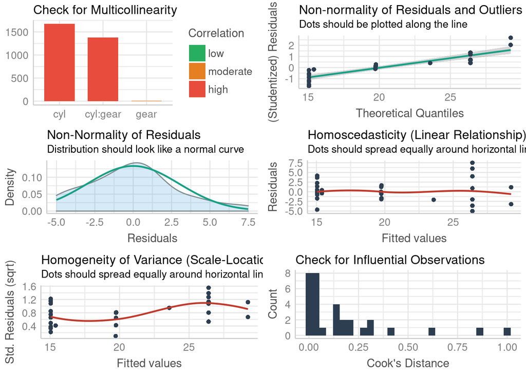

```r
check_model(aov1)
```

What about outliers? Let’s do a visual and a numerical check

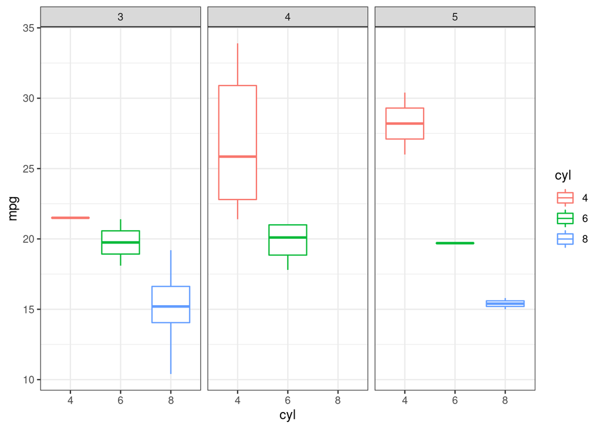

```r
ggplot(data=mtcars, aes(x=cyl, y=mpg, color=cyl))+
  geom_boxplot()+
  theme_bw()+
  facet_wrap(~gear)
```

```r
mtcars %>%
  group_by(cyl, gear) %>%
  identify_outliers(mpg) #No extreme outliers, so let's carry on
```

| cyl | gear | mpg | disp | hp | drat | wt | qsec | vs | am | carb | is.outlier | is.extreme |
| --- | --- | --- | --- | --- | --- | --- | --- | --- | --- | --- | --- | --- |

Let’s revisit our ANOVA and interpret it!

```r
summary(aov1)
```

```
##             Df Sum Sq Mean Sq F value   Pr(>F)
## cyl          2  824.8   412.4  38.606 1.64e-08 ***
## gear         1    7.0     7.0   0.652    0.427
## cyl:gear     2   16.6     8.3   0.775    0.471
## Residuals   26  277.7    10.7
## ---
## Signif. codes:  0 '***' 0.001 '**' 0.01 '*' 0.05 '.' 0.1 ' ' 1
```

This shows us that there is a significant effect of cylinder on mpg. However, there is no effect of gear of of the interaction of cyl and gear (cyl:gear). This type of ANOVA is called an interactive two-way anova.

When building an ANOVA (or any statistical model) there are two ways to look at multiple factors. We can do additive (+) or interactive (*). Additive tests the effects of each variable seperately. Interactive does the same plus an interaction term.

Let’s look at the difference

```r
aov1<-aov(mpg~cyl*gear, data=mtcars)
summary(aov1)
```

```
##             Df Sum Sq Mean Sq F value   Pr(>F)
## cyl          2  824.8   412.4  38.606 1.64e-08 ***
## gear         1    7.0     7.0   0.652    0.427
## cyl:gear     2   16.6     8.3   0.775    0.471
## Residuals   26  277.7    10.7
## ---
## Signif. codes:  0 '***' 0.001 '**' 0.01 '*' 0.05 '.' 0.1 ' ' 1
```

```r
aov2<-aov(mpg~cyl+gear, data=mtcars)
summary(aov2)
```

```
##             Df Sum Sq Mean Sq F value   Pr(>F)
## cyl          2  824.8   412.4  39.236 7.57e-09 ***
## gear         1    7.0     7.0   0.663    0.422
## Residuals   28  294.3    10.5
## ---
## Signif. codes:  0 '***' 0.001 '**' 0.01 '*' 0.05 '.' 0.1 ' ' 1
```

We see that the p-values are slightly different here and that the additive anova does not include an interaction term. When do you think we might need additive vs. interactive? Does it really matter? The answer is really dependent upon your question!

You can use as many terms as you want in an anova, but the more you use the smaller the sample size will get and the harder it will be to interpret. We will talk about best practices in model building next week if we have time.

For now, we have 1 more thing to learn! We have used ANOVA to determine that there is an effect of cyl on mpg. But, which groups within cylinders are different from each other?

For that, we need post-hoc tests!

## **TUKEY Honestly Significant Difference test (HSD)**

First, let’s look at our data. We saw from our ANOVA that there is a significant effect of cyl on mpg

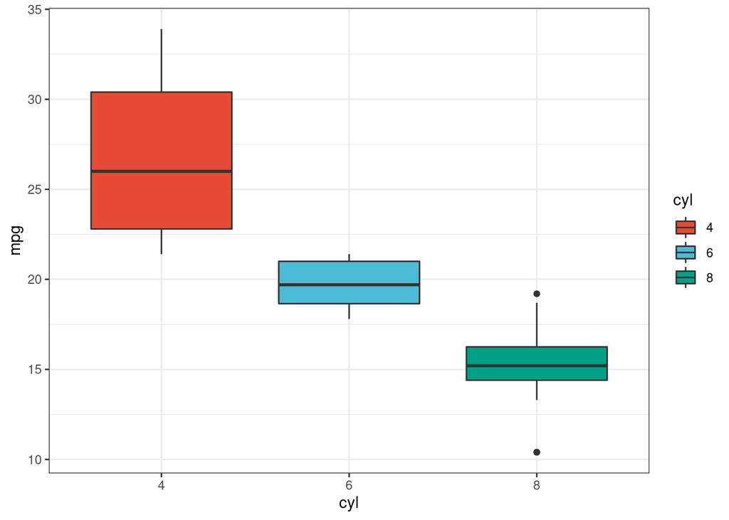

```r
ggplot(data=mtcars, aes(x=cyl, y=mpg, fill=cyl))+
  geom_boxplot()+
  theme_bw()+
  scale_color_npg()+
  scale_fill_npg()
```

```r
aovtest<-aov(mpg~cyl, data=mtcars)
summary(aovtest)
```

```
##             Df Sum Sq Mean Sq F value   Pr(>F)
## cyl          2  824.8   412.4    39.7 4.98e-09 ***
## Residuals   29  301.3    10.4
## ---
## Signif. codes:  0 '***' 0.001 '**' 0.01 '*' 0.05 '.' 0.1 ' ' 1
```

Great, we know about that effect. But which number of cylinders gives us the best mpg? It looks like 4 is the answer. But we still don’t know! That is really what our hypothesis is most likely the be!

To test that, we need to do a post-hoc test. I like the TUKEY honest significant difference test (which functions like a bnunch of t-tests all at once)

Here is how we do it!

```r
aovtest<-aov(mpg~cyl, data=mtcars)
TukeyHSD(aovtest)
```

```
##   Tukey multiple comparisons of means
##     95% family-wise confidence level
##
## Fit: aov(formula = mpg ~ cyl, data = mtcars)
##
## $cyl
##           diff        lwr        upr     p adj
## 6-4  -6.920779 -10.769350 -3.0722086 0.0003424
## 8-4 -11.563636 -14.770779 -8.3564942 0.0000000
## 8-6  -4.642857  -8.327583 -0.9581313 0.0112287
```

The Tukey shows us comparisons of each cylinder category with one another. We see that There are significant differences between all 3 groups! This tells us definitely, that MPG is highest with 4 cylinders and lowest with 8.

# **5.) Linear Regression**

## **Intro to Linear Regression**

There are 3 main types of data distribution. Each type of distribution requires different statistical procedures.

We have already talked about **Normal Distributions** (aka: bell curves or Gaussian). We can use ANOVA, t-test, and simple linear regression on this type of data. We have also talked about how we might be able to use ANOVA approaches on non-normal distributions (with some caveats).

Below are the three main types of data distributions.

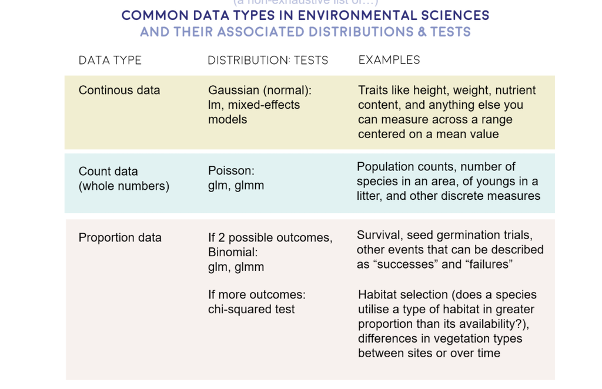

distributions - ourcodingclub

Note: it is possible for a Poisson distribution to look like a normal distribution. The “Examples” section of the graphic can be very helpful in knowing which type of analysis to choose!

Here, the graphic shows us that for continuous data (usually approximately normal) we can use ANOVA, lm (linear regression), or mixed effects models (we MIGHT learn this later if there is time).

For count data, including population counts and abundance counts, we usually have a poisson distribution. If that is the case we want to use glm or Generalized Linear Models. Again, the intricacies of these can be really complicated. As such, we **WILL NOT** get to glm and linear mixed effects models as a class this semester. I will be teaching these approaches in my research methods course next term (ecology capstone) and am happy to help you explore them this term if you are interested. For now, I recognize that we may not be able to choose “the best” statistical models for our data, but we can still learn how to use some models test assumptions to understand our limitations.

For survival data or binomial data like “presence vs absence” we often have a binomial distribution. Here we also want to use glm.

**Importantly** Model selection and model structure should be driven by your hypothesis. Fitting the “best” model doesn’t always allow us to address our hypothesis so we will need to learn how to make judgment calls that allow us to find the best model that still addresses our question!

## **Linear regression theory**

A linear regression essentially compare the correlation of one variable with another. The closer the relationship is to 1:1 (a diagonal line at 45 degrees from the x and y axis) the more correlated the two variables are. Does correlation imply causation? NO, it does not. But this type of analysis driven by hypotheses can help us seek causation/ mechanisms and statistically assess relationships.

Linear regressions are not very differnt from ANOVA. They gave 4 assumptions:

1.) Linearity of the data: We assume the relationship between predictor (x) and outcome/dependent variable (y) is approx. linear

2.) Normaliy of residuals: The residual errorr are assumed to be normally distributed

3.) Homogeneity of residual variance (homoscedasticity): We assume residual variance is approx. constant

4.) Independence of residual error terms

**WE NEED TO CHECK THE FOLLOWING WHEN USING LINEAR REGRESSION**

**1.) Non-linearity** **2.) Homescedasticity** **3.) Presence of influential values** (outliers in the outcome(y) variable and extreme values in the predictor (x) variable).

We can do ALL of this very quickly and easily using our old friend the “performance” package :) We simply need to use:

check_model()

(YAY, finally something easy :) )

Ok, let’s apply this theory and test out some basic lm

## **Simple linear regression**

In R, we can do a simple linear regression (or linear model) with the function lm() from base R.

Let’s run through an example using iris and test the assumptions. You’ll note that this is VERY similar to assumption checking w/ ANOVA.

```r
head(iris)
```

| Sepal.Length | Sepal.Width | Petal.Length | Petal.Width | Species |
| --- | --- | --- | --- | --- |
| 5.1 | 3.5 | 1.4 | 0.2 | setosa |
| 4.9 | 3.0 | 1.4 | 0.2 | setosa |
| 4.7 | 3.2 | 1.3 | 0.2 | setosa |
| 4.6 | 3.1 | 1.5 | 0.2 | setosa |
| 5.0 | 3.6 | 1.4 | 0.2 | setosa |
| 5.4 | 3.9 | 1.7 | 0.4 | setosa |

FIRST, we need to generate a hypothesis. Let’s hypothesize that sepal length will scale positively with sepal width (longer sepals will also be wider). Now, we build out linear regression. In this case, Sepal.Length is our predictor var so it is our x variable. Sepal.Width is our outcome/dependent variable so it is our y variable. In lm() we use this notation lm(y~x) or Y in terms of X

```r
irislm<- lm(Sepal.Width ~ Sepal.Length, data=iris)

summary(irislm)
```

```
##
## Call:
## lm(formula = Sepal.Width ~ Sepal.Length, data = iris)
##
## Residuals:
##     Min      1Q  Median      3Q     Max
## -1.1095 -0.2454 -0.0167  0.2763  1.3338
##
## Coefficients:
##              Estimate Std. Error t value Pr(>|t|)
## (Intercept)   3.41895    0.25356   13.48   <2e-16 ***
## Sepal.Length -0.06188    0.04297   -1.44    0.152
## ---
## Signif. codes:  0 '***' 0.001 '**' 0.01 '*' 0.05 '.' 0.1 ' ' 1
##
## Residual standard error: 0.4343 on 148 degrees of freedom
## Multiple R-squared:  0.01382,    Adjusted R-squared:  0.007159
## F-statistic: 2.074 on 1 and 148 DF,  p-value: 0.1519
```

## **Interpreting your linear regression (R^2 and p-value)**

What does all that output mean? Here is an annotated example to help us learn…

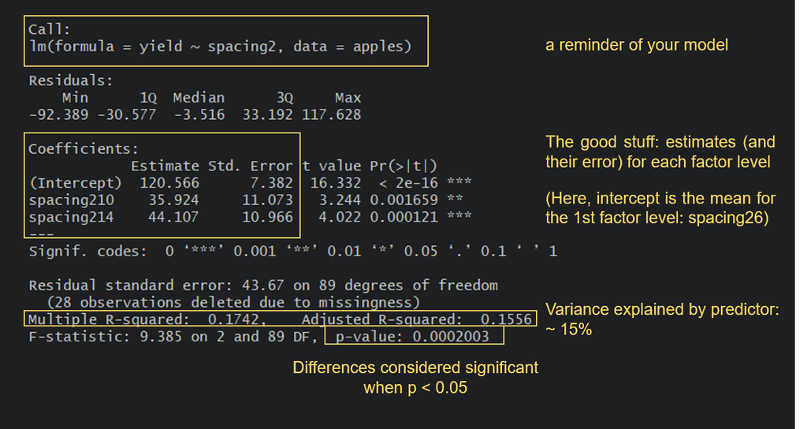

lm_output - ourcodingclub

At the top of the output we see a reminder or our model structure. This will become more useful when we do more complex models.

In the middle we see a table of coefficients. This should look kind of like the output from ANOVA. Estimate tells us the mean effect size of each of our variables. This is not overly useful for us this time, so let’s talk about this table in the next example. Notably, since x is continous and not categorical, (Intercept) is the values of x when y = 0.

Further down, we see the values we really care about for a SIMPLE linear model (R-squared and p-value). The R-squared tells us how much of the variance is explained by the predictor (Sepal.Length). In other words, this tells us how close to a 1:1 line our model is, where R-squared nearer to 1 is best and closer to 0 is worse (less correlation). We want to look at adjusted R-squared, which we see is VERY low (0.007). We can visualize this with a graph…

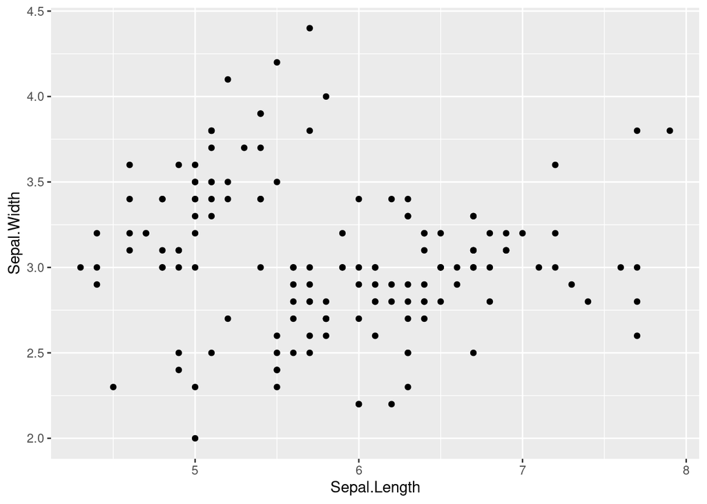

```r
ggplot(data=iris, aes(x=Sepal.Length, y=Sepal.Width))+
  geom_point()
```

As we can see, there is NOT a clear linear relationship here. Our R-squared value tells us the same thing. The p-value is also not <0.05, indicating that there is NOT a significant linear relationship between sepal length and width. As such, we can REJECT our hypothesis that longer sepals will be wider.

To visualize this, we can actually make an lm on our ggplot :)

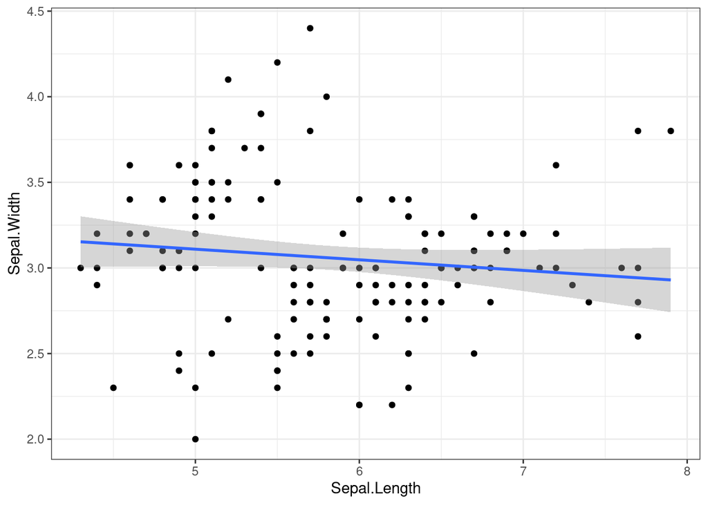

```r
ggplot(data=iris, aes(x=Sepal.Length, y=Sepal.Width))+
  geom_point()+
  geom_smooth(method=lm)+
  theme_bw()
```

## **checking assumptions**

We can just use check_model in the “performance” package to quickly look at them…

```r
check_model(irislm)
```

```
## Not enough model terms in the conditional part of the model to check for multicollinearity.
```

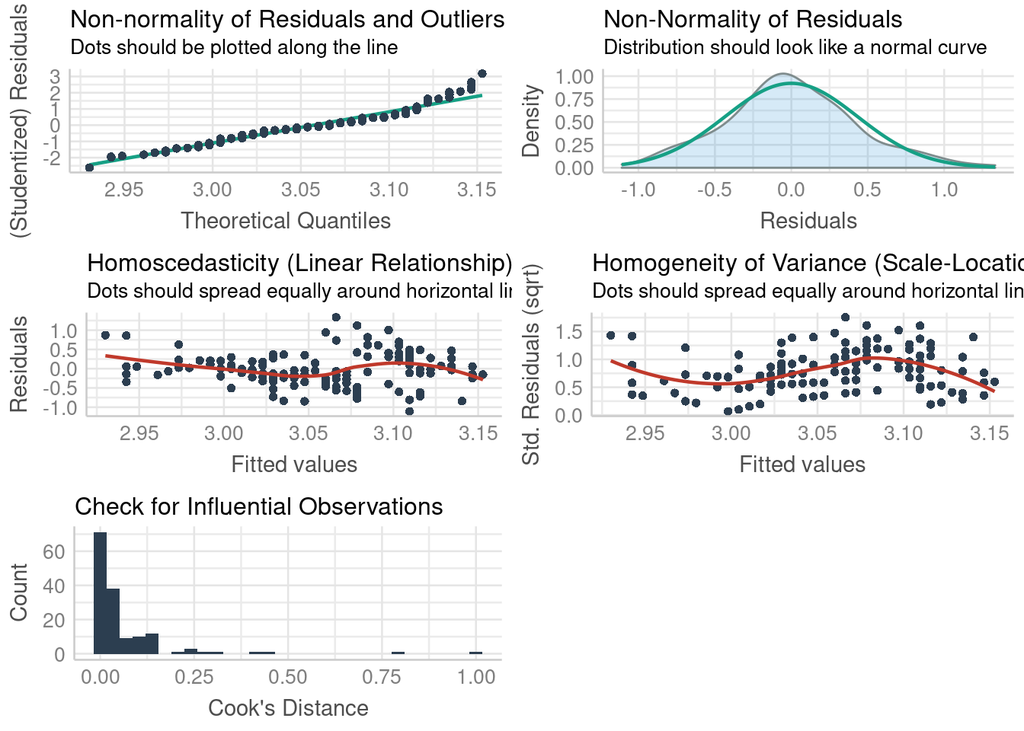

Here we see that we have nearly normal residuals, a nearly normal distribution, SOME concerns about homoscedasticity (but overall, it seems mostly fine), and reasonable homogeneity of variance. The last plot (Cook’s Distance) shows us influential observations. Unless Cook’s distance is >1 (x-axis) we don’t need to worry. So here, we are good! In short, our model was acceptable so we can trust what we saw!

## **Linear models with categorical variables**

Let’s make this a little more interesting…

We can look at mtcars this time…

```r
head(mtcars)
```

|  | mpg | cyl | disp | hp | drat | wt | qsec | vs | am | gear | carb |
| --- | --- | --- | --- | --- | --- | --- | --- | --- | --- | --- | --- |
| Mazda RX4 | 21.0 | 6 | 160 | 110 | 3.90 | 2.620 | 16.46 | 0 | 1 | 4 | 4 |
| Mazda RX4 Wag | 21.0 | 6 | 160 | 110 | 3.90 | 2.875 | 17.02 | 0 | 1 | 4 | 4 |
| Datsun 710 | 22.8 | 4 | 108 | 93 | 3.85 | 2.320 | 18.61 | 1 | 1 | 4 | 1 |
| Hornet 4 Drive | 21.4 | 6 | 258 | 110 | 3.08 | 3.215 | 19.44 | 1 | 0 | 3 | 1 |
| Hornet Sportabout | 18.7 | 8 | 360 | 175 | 3.15 | 3.440 | 17.02 | 0 | 0 | 3 | 2 |
| Valiant | 18.1 | 6 | 225 | 105 | 2.76 | 3.460 | 20.22 | 1 | 0 | 3 | 1 |

Now, I want to hypothesize that there will be no effect of cylinder on horsepower (this is called a “null hypothesis”). We’ve seen similar hypothesis before in our ANOVA.

First, let’s make cylinder a factor and plot a boxplot so we can see whether there may be a trend here…

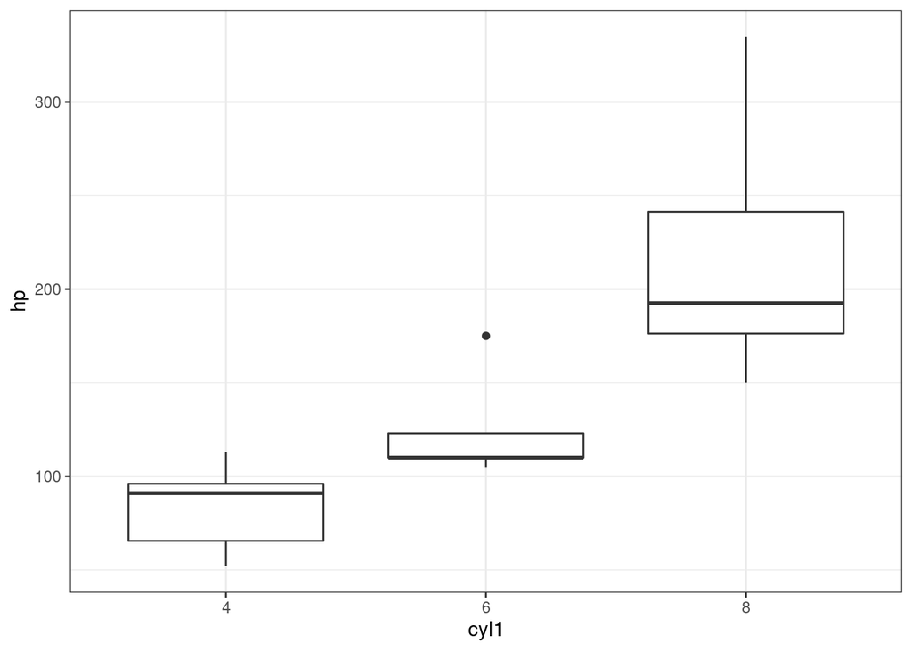

```r
mtcars$cyl1=as.factor(mtcars$cyl)

ggplot(mtcars, aes(x=cyl1, y=hp))+
         geom_boxplot()+
         theme_bw()
```

I think it is safe to say we see what we might suspect to be a linear(ish) relationship between cyl and hp, where hp increases as cyl increases. What do you think?

Now, let’s do some stats on this.

```r
lmhp<-lm(hp~cyl1, data = mtcars)
summary(lmhp)
```

```
##
## Call:
## lm(formula = hp ~ cyl1, data = mtcars)
##
## Residuals:
##    Min     1Q Median     3Q    Max
## -59.21 -22.78  -8.25  15.97 125.79
##
## Coefficients:
##             Estimate Std. Error t value Pr(>|t|)
## (Intercept)    82.64      11.43   7.228 5.86e-08 ***
## cyl16          39.65      18.33   2.163   0.0389 *
## cyl18         126.58      15.28   8.285 3.92e-09 ***
## ---
## Signif. codes:  0 '***' 0.001 '**' 0.01 '*' 0.05 '.' 0.1 ' ' 1
##
## Residual standard error: 37.92 on 29 degrees of freedom
## Multiple R-squared:  0.7139, Adjusted R-squared:  0.6941
## F-statistic: 36.18 on 2 and 29 DF,  p-value: 1.319e-08
```

Further down, we see an R-squared of nearly 0.70, which is very good evidence of a linear relationship (70% of the variance in y can be explained by x!). The p-value is very nearly 0.00, which indicates a significant linear correlation.

**Let’s check assumptions!**

```r
check_model(lmhp)
```

```
## Not enough model terms in the conditional part of the model to check for multicollinearity.
```

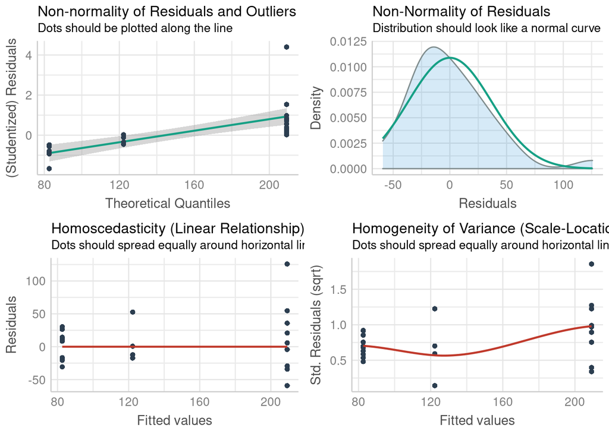

Here we see some concern about Homoscedasticity and homogeneity of variance. We can probably still assume our model is reliable, but we may want to be careful. We learned ways to numerically assess this last week, but again, with high enough sample size, this won’t be an issue. Here, I would suggest that n is too small, so if this were a real statistical test we would have limitations to discuss.

Remember our hypothesis (null) was: “There will be no effect of cylinder on horsepower.” We are able to reject this null hypothesis and suggest that indeed horsepower increases as cylinder increases. We might also add caveats that homoscedasticity was not confirmed due to low sample size, but the result seems clear enough that this likely doesn’t matter. ***

## **ONE MORE TEST of lm –> more complexity :)**

let’s go back to iris

```r
head(iris)
```

| Sepal.Length | Sepal.Width | Petal.Length | Petal.Width | Species |
| --- | --- | --- | --- | --- |
| 5.1 | 3.5 | 1.4 | 0.2 | setosa |
| 4.9 | 3.0 | 1.4 | 0.2 | setosa |
| 4.7 | 3.2 | 1.3 | 0.2 | setosa |
| 4.6 | 3.1 | 1.5 | 0.2 | setosa |
| 5.0 | 3.6 | 1.4 | 0.2 | setosa |
| 5.4 | 3.9 | 1.7 | 0.4 | setosa |

While looking at these data I might think that species impacts the relationsip between petal length and petal width. I might generate the following null hypothesis: “Species has no effect on the relationship between petal length and petal width”

Let’s visualize this…

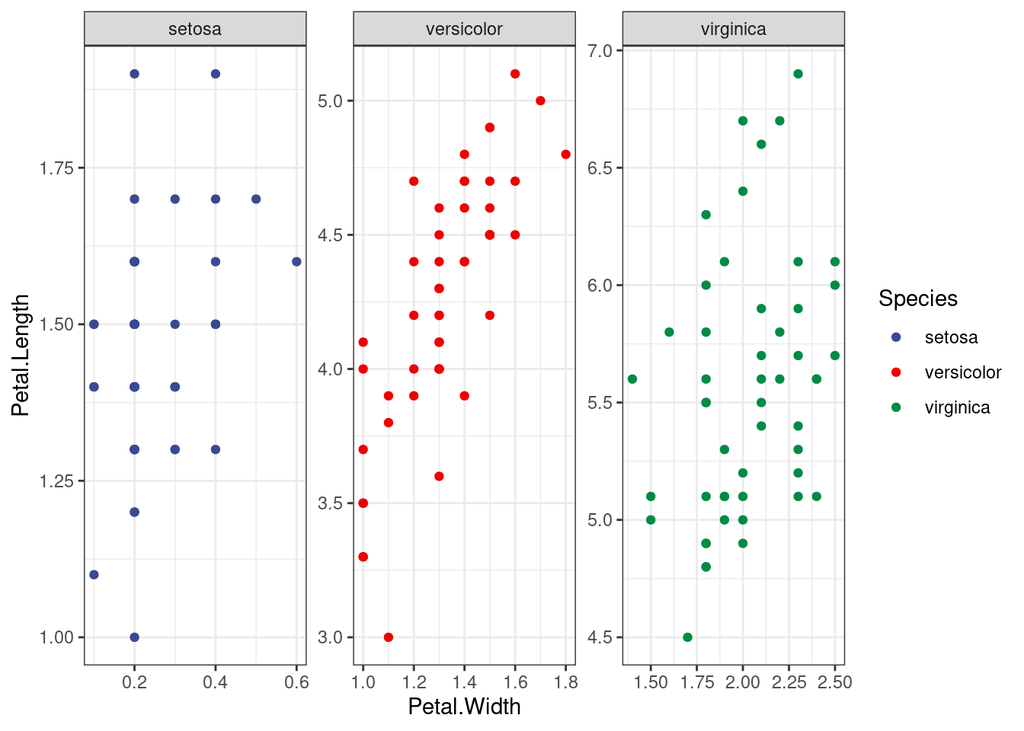

```r
ggplot(data=iris, aes(x=Petal.Width, y=Petal.Length, group=Species, color=Species))+
  geom_point()+
  facet_wrap(~Species, scales='free')+ #scales='free' allows the x and y ranges to vary by facet. This lets us have a better look at the comparison between petal width and length for each species
  theme_bw()+
  scale_color_aaas()
```

What we see here is unclear. Let’s try to put an lm() layer on this and then look at some stats.

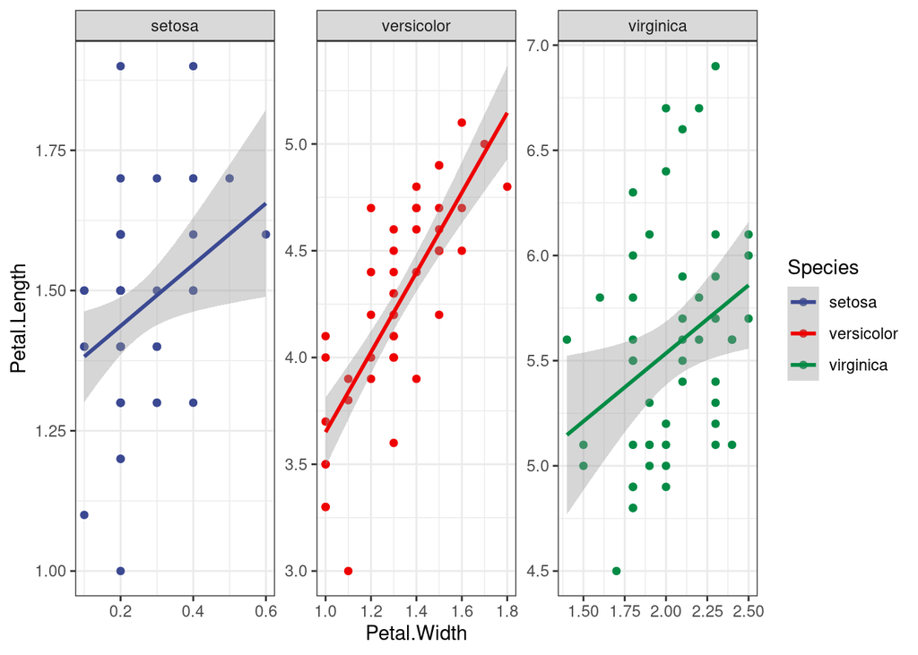

```r
ggplot(data=iris, aes(x=Petal.Width, y=Petal.Length, color=Species))+
  geom_point()+
  facet_wrap(~Species, scales='free')+
  geom_smooth(method=lm)+
  theme_bw()+
  scale_color_aaas()
```

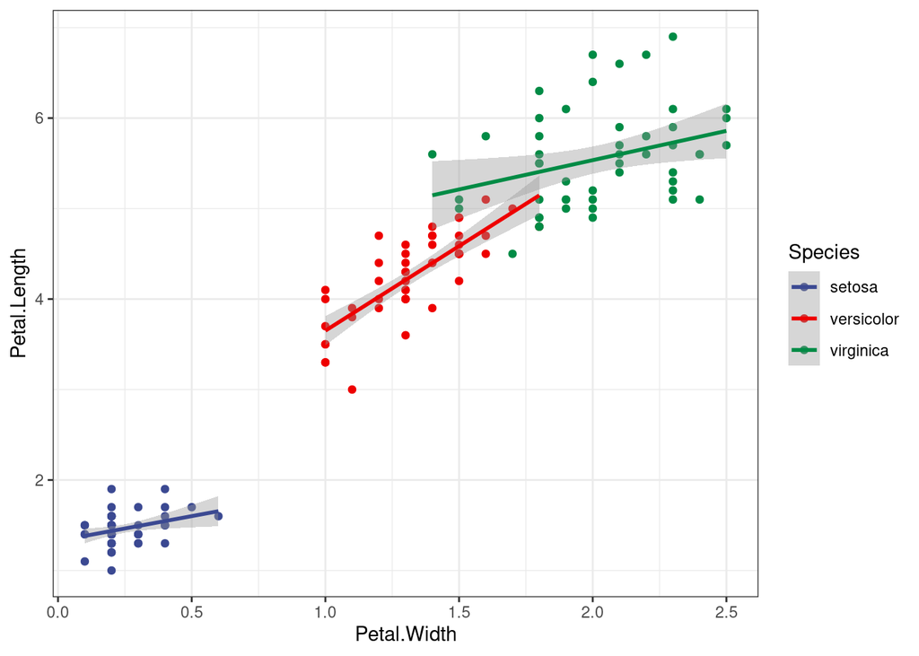

```r
ggplot(data=iris, aes(x=Petal.Width, y=Petal.Length, color=Species))+
  geom_point()+
  #facet_wrap(~Species, scales='free')+
  geom_smooth(method=lm)+
  theme_bw()+
  scale_color_aaas()
```

This visualization shows us that there are probably positive linear correlation between petal width and length but that the exact correlation varies by species.

Let’s test out an interactive lm (using ‘+’ (additive) will give us insights into how intercepts change, using interactive will also give us insights into how slopes change!)

```r
specieslm<-lm(Petal.Length ~ Petal.Width * Species, data=iris)
summary(specieslm)
```

```
##
## Call:
## lm(formula = Petal.Length ~ Petal.Width * Species, data = iris)
##
## Residuals:
##      Min       1Q   Median       3Q      Max
## -0.84099 -0.19343 -0.03686  0.16314  1.17065
##
## Coefficients:
##                               Estimate Std. Error t value Pr(>|t|)
## (Intercept)                     1.3276     0.1309  10.139  < 2e-16 ***
## Petal.Width                     0.5465     0.4900   1.115   0.2666
## Speciesversicolor               0.4537     0.3737   1.214   0.2267
## Speciesvirginica                2.9131     0.4060   7.175 3.53e-11 ***
## Petal.Width:Speciesversicolor   1.3228     0.5552   2.382   0.0185 *
## Petal.Width:Speciesvirginica    0.1008     0.5248   0.192   0.8480
## ---
## Signif. codes:  0 '***' 0.001 '**' 0.01 '*' 0.05 '.' 0.1 ' ' 1
##
## Residual standard error: 0.3615 on 144 degrees of freedom
## Multiple R-squared:  0.9595, Adjusted R-squared:  0.9581
## F-statistic: 681.9 on 5 and 144 DF,  p-value: < 2.2e-16
```

The R2 of our overall model is 0.95!, and p is ~ 0.0, so we have a clearly significant relationship here.

Finally, let’s test assumptions

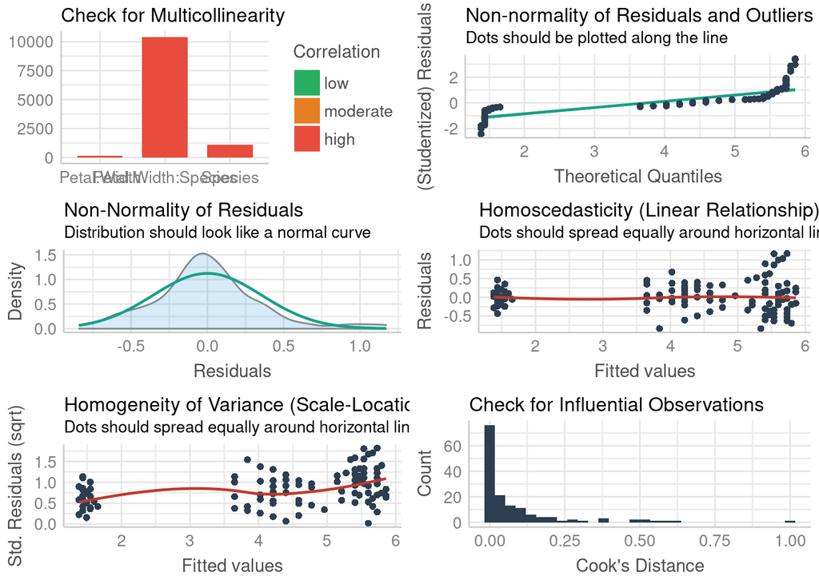

```r
check_model(specieslm)
```

Right away, the first panel here shows us that we have HIGH multicollinearity, which is something we have not talked about yet. This essentially means that the predictors we used are highly correlated. This usually indicates that the variables are NOT independent of one another. IF we get into more complex modelling we can worry about this, but a way to eliminatae this would be to pull the effect of species out of our model. However, doing this, while it might make the “best” statistical model, will no longer allow us to address our hypothesis, so we need to make a judgement call here. This time, I elect to keep everything in the model.

Luckily, we see nice data for normality of residuals, so that’s great. Homoscedasticity actually looks decent for once, and there are no clear influential observations. In short, we really did ok here. We can assume this model is reliable.

Now, let’s go back to our null hypothesis: “Species has no effect on the relationship between petal length and petal width”

We can reject this null hypothesis as we had a very low p-value on our model. We can instead say that there is a significant positive linear correlation between petal length and petal width that varies in slope based on species. To take this even further, we can say that the slopes of setosa and virginica do not differ but the slopes of setosa and versicolor do! By looking at our plot, we can see that the correlation is stronger in versicolor than it is in the other two species!

# **6.) Applying what we’ve learned**

1.) Grab some data and generate a hypothesis about it (a difference between groups? No differences? You can choose!) 2.) calculate means and error ranges and plot 3.) Run a suitable ANOVA (and Tukey if necessary) to match your graph and hypothesis 4.) Evaluate your statistical test. Were assumptions met? Can they be ignored? What is the outcome of the statistical test? Was your hypothesis incorrect? 5.) Apply the same procedure for linear regression: develop a hypothesis, plot (w/ regression line) and carry our the linear regression test. Evaluate the linear regression. What does it tell you about your hypothesis?